# Preprocessing and Visualization

#### pandas review

`pandas` is a useful library for storing and manipulating data in Python. It features useful integrations with other popular libraries, like `scikit-learn` and `seaborn`. The core object of `pandas` is the `DataFrame`, which acts as a table for various types of data. Here, we'll create a dummy `DataFrame` by passing in a dictionary of arbitrary values. In this case, the dictionary keys will act as column names, while their values will populate the table rows.

```python
import pandas as pd

df = pd.DataFrame({'A': np.power(np.array([1, 2, 3, 4, 5, 6]), 2),
                   'B': pd.date_range('20200303', periods=6),
                   'C': pd.Categorical(["red", "blue", "green", "green", "red", "yellow"]),
                   'D': 'foo',
                   'E': np.random.randn(6)})
```

To see what a `DataFrame` looks like, we can look at its first and last $N$ elements.

```python
# Get first N elements of the DataFrame if specified, 5 otherwise

print(df.head(3))

# Get last N elements of the DataFrame if specified, 5 otherwise

print(df.tail(3))
```

```
   A          B      C    D         E
0  1 2020-03-03    red  foo -0.041059
1  4 2020-03-04   blue  foo -0.369706
2  9 2020-03-05  green  foo  0.530468
    A          B       C    D         E
3  16 2020-03-06   green  foo -0.049920
4  25 2020-03-07     red  foo  0.245107
5  36 2020-03-08  yellow  foo  0.777110
```

We can see the type of element belonging to each column.

```python
print(df.dtypes)
```

```
A             int64
B    datetime64[ns]
C          category
D            object
E           float64
dtype: object
```

We can also view a statistical summary of all relevant columns. Here, columns "A" and "E" are the only continuous variables that can be used for calculation.

```python
print(df.describe())
```

```
               A         E
count   6.000000  6.000000
mean   15.166667  0.182000
std    13.377842  0.421305
min     1.000000 -0.369706
25%     5.250000 -0.047705
50%    12.500000  0.102024
75%    22.750000  0.459128
max    36.000000  0.777110
```

If we need to access specific values or ranges of values, there is a variety of ways to do so.

```python
# Return specified column

print(df["C"])

# Return 1st row

print(df.iloc[0])

# Return rows 2 to 4

print(df.iloc[1:4])

# Return rows 2 to 4, second and third columns

print(df.iloc[1:4,1:3])
```

```
0       red
1      blue
2     green
3     green
4       red
5    yellow
Name: C, dtype: category
Categories (4, object): [blue, green, red, yellow]
A                      1
B    2020-03-03 00:00:00
C                    red
D                    foo
E             -0.0410595
Name: 0, dtype: object
    A          B      C    D         E
1   4 2020-03-04   blue  foo -0.369706
2   9 2020-03-05  green  foo  0.530468
3  16 2020-03-06  green  foo -0.049920
           B      C
1 2020-03-04   blue
2 2020-03-05  green
3 2020-03-06  green
```

We can also load data from character-delimited files (`.csv` or `.tsv`) directly into `pandas`. Here, we'll load a table containing the per-epoch loss and accuracy when training a neural dependency parser on a Finnish treebank.

```python
training = pd.read_csv("../files/fi_tdt_training.csv")

print(training.head())
```

```
   epoch      loss   dev_uas   dev_las
0      0  8.667959  0.554785  0.470505
1      1  3.225573  0.639611  0.561285
2      2  2.527456  0.728042  0.653922
3      3  2.116891  0.784739  0.719358
4      4  1.896505  0.806751  0.744319
```

#### Understanding variable relationships

Before plotting, it is important to understand what sort of variables you're working with. In most situations, like in supervised learning, you'll be concerned with two variables: an X and a Y. Unlike supervised learning, however, you shouldn't always think of these as your input and output. Instead, you can refer to them as *independent* and *dependent* variables, respectively. Another name for these is *explanatory* and *response* variables, depending on what field you're in.

To understand the relationship between the two, imagine tracking how quickly 100 people finished a 5km race. You have a data point for each individual racer, specifying their time in minutes. Imagine also that, prior to the race, you measured the height of each participant and now you want to visualize how these two variables interact. If you think in terms of dependence / independence, it might be intuitive to imagine the race time as the *dependent* (or *response*) variable, and the height as the *independent* (or explanatory) variable. In other words, how quickly someone finishes the race might *depend* on the racer's height. You cannot say the same for the opposite scenario: how tall someone is not dependent on the person's finish time in a 5K. With this formulation, we can revisit the problem in terms of supervised learning, where our *dependent* variable is the output of some function over our independent variable: $Y = f(X)$. With this in mind, when we're generating 2D plots, the convention is to place the independent variable on the X-axis and the dependent variable on the Y-axis.

#### Continuous vs. Discrete variables

When dealing with variables in statistics, there are typically two that we're concerned with: *continuous* and *discrete* variables. These are sometimes also called *numeric* and *categorical* variables, respectively. The difference between the two is subtle, but crucial.

*Continuous* variables are those which can take infinite values within a specified range. Again, you can think of this in terms of human height. One's height is typically measured with 2-point precision (e.g. 1.87 meters), but this number can be infinitely precise (1.872847329483729843298473298743432897432 meters), just not infinitely measurable. Within the range of plausible human heights, it would be impossible to enumerate all values. The same can be said of other such variables, such as the speed of a car, degree of temperature, accuracy of a classifier, etc.

*Discrete* variables are those which can be counted in finite time by whole numbers. You can think of this in terms of categories. Say, instead of measuring one's height directly, we gave them a ballpark classification of "short" or "tall". There is no *range* here, per sé, just the two levels of "short" and "tall. We can't assign any reasonable value to someone that is of "average" height, since we only have two categories. Other examples of discrete variables might be biological sex, days of the week, or even a binary choice (yes or no).

#### Scatter plots

Scatterplots are typically the go-to plot when both variables you're working with are numeric (e.g. continuous). Let's generate some random numbers and visualize them using a scatter plot.

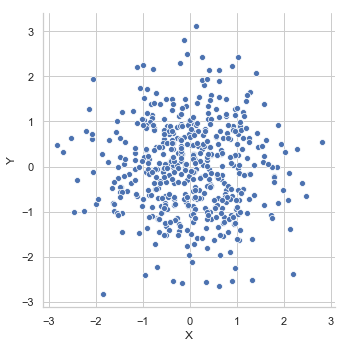

```python
import numpy as np
import matplotlib.pyplot as plt
import seaborn as sns
import pandas as pd

%matplotlib inline

sns.set(style="whitegrid")

df1 = pd.DataFrame(dict(X=np.random.randn(500),
                       Y=np.random.randn(500)))

scatter1 = sns.relplot(x="X", y="Y",
                      data=df1, kind="scatter")
```

If we have an additional (discrete) variable that we'd like to categorize the data by, we can use color to differentiate between samples.

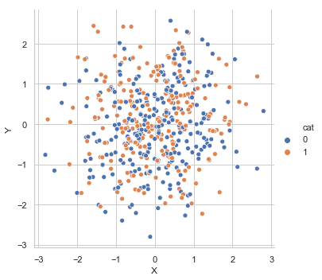

```python
df2 = pd.DataFrame(dict(X=np.random.randn(500),
                       Y=np.random.randn(500),
                       cat=np.random.randint(2, size=500)))

scatter2 = sns.relplot(x="X", y="Y", hue="cat",
                      data=df2, kind="scatter")
```

... we can also use point styles...

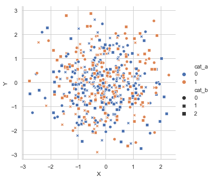

```python
df3 = pd.DataFrame(dict(X=np.random.randn(500),
                       Y=np.random.randn(500),
                       cat_a=np.random.randint(2, size=500),
                       cat_b=np.random.randint(3, size=500)))

scatter3 = sns.relplot(x="X", y="Y", hue="cat_a", style="cat_b",
                      data=df3, kind="scatter")
```

... as well as size...

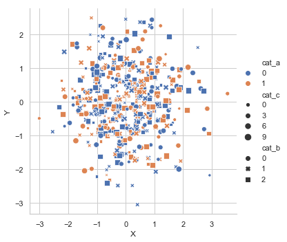

```python
df4 = pd.DataFrame(dict(X=np.random.randn(500),
                       Y=np.random.randn(500),
                       cat_a=np.random.randint(2, size=500),
                       cat_b=np.random.randint(3, size=500),
                       cat_c=np.random.randint(10, size=500)))

scatter4 = sns.relplot(x="X", y="Y", hue="cat_a", style="cat_b", size="cat_c",
                      data=df4, kind="scatter")
```

We can also fit a regression to visualize the relationship between our variables.

[figure not shown]

```python
reg = sns.regplot(x="X", y="Y", data=df1)
```

#### Line plots

If our independent variable is a continuous variable --- or even a discrete variable that can be sorted as some function of time --- it might be better to draw a line plot. Here we'll visualize the loss, dev UAS, and dev LAS of a neural dependency parser as a function of training epoch.

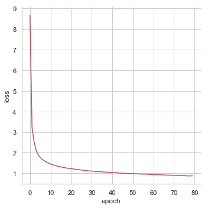

```python
training_plot = sns.relplot(x="epoch", y="loss", color="r",
                            kind="line", data=training)
```

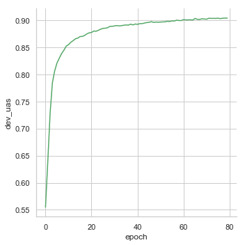

```python
uas_plot = sns.relplot(x="epoch", y="dev_uas", color="g",
                       kind="line", data=training)
```

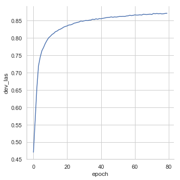

```python
las_plot = sns.relplot(x="epoch", y="dev_las", color="b",
                       kind="line", data=training)
```

```
(0.4, 1.0)
```

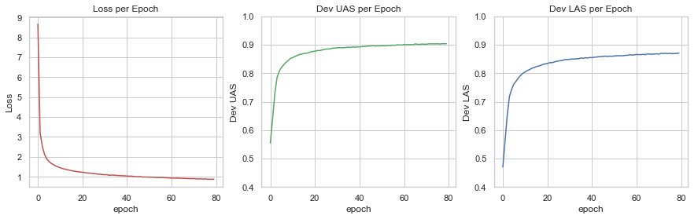

```python
fig, (ax1, ax2, ax3) = plt.subplots(1, 3, figsize=(15, 4))

loss = sns.lineplot(x="epoch", y="loss", color="r",
                   data=training, ax=ax1)

uas = sns.lineplot(x="epoch", y="dev_uas", color="g",
                  data=training, ax=ax2)

las = sns.lineplot(x="epoch", y="dev_las", color="b",
                  data=training, ax=ax3)

ax1.set_title("Loss per Epoch")
ax2.set_title("Dev UAS per Epoch")
ax3.set_title("Dev LAS per Epoch")
ax1.set_ylabel("Loss")
ax2.set_ylabel("Dev UAS")
ax3.set_ylabel("Dev LAS")
ax2.set_ylim(0.4 ,1.0)
ax3.set_ylim(0.4 ,1.0)
```

#### Bar plots

```python
counts = ent_counter(processed_speeches,
                     ent_label = "GPE",
                     n=10)

top_10_places = pd.DataFrame(dict(ent_label = [ent[0] for ent in counts],
                                  ent_count = [ent[1] for ent in counts]))

place_plot = sns.catplot(x="ent_label", y="ent_count",
                         kind="bar", palette="colorblind",
                         data=top_10_places)

place_plot.set_xticklabels(rotation=90)
```

[output not shown]

[output not shown]

This will complete the lecture on preprocessing and visualization. You should now have a good grasp of the toolkits to work with when cleaning and looking at data. In the next lecture we'll employ some of the concepts we've learned here to write and deploy a self-standing Python package.